# Climate Impact on Agricultural Productivity

Project Report for STAT 303-1 Fall 2025

Author

Sophia Perez

Published

December 9, 2025

Abstract

This study integrates four analytical approaches to assess how climate change influences crop yields and broader economic outcomes. First, these analytical questions allow for the study of how climate and agriculture vary over time and on a regional level. Across analyses, temperature patterns and extreme weather events consistently emerged as the primary drivers of agricultural performance. While global temperature trends showed no strong temporal patterns, regional analyses revealed substantial geographic variation, indicating that climate impacts are more meaningfully interpreted at the regional scale. Furthermore, the analysis questions worked to answer how well climate change variables correlated with crop yield and how they affect the economy. A key global finding shows that crop yields peak within an average temperature range of 10–20°C. Activity of Very High extreme weather event levels has also increased in recent years, is most frequent in the United States, and coincides with relatively higher U.S. crop yields under severe conditions. Economic impact also showed a strong positive linear relationship with crop yield. These findings together highlight the need for region-specific climate policies and agricultural investments that enhance crop and soil resilience against climate change events, which can overall have an impact on economic welfare.

## 1) Inspiration

- The reason I chose this data is that I find it interesting how climate change can have an impact on various social, agricultural, and economic factors, which can diminish overall well-being. I specifically chose this dataset on agriculture because of both past experiences and my passion for cooking.
- My parents both grew up in Colombia and moved to the United States as adults, which has allowed my siblings and me to visit the country regularly. During one of these trips, we toured El Parque del Café, where we had the opportunity to walk through a Colombian coffee plantation, harvest coffee beans, and observe the full processing workflow. We were also able to see similar production processes for sugarcane and cacao. This experience significantly deepened my interest in agricultural systems, particularly given my personal passion for cooking and my reliance on processed agricultural ingredients in everyday life.
- I think the dataset is worth exploring for this project because agriculture is a necessity for human life, and climate change has become more prominent in recent years. Analyzing this dataset could reveal patterns that can lead to solutions to this ever-evolving issue.

## 2) Problem Statements

1. What are overall trends and patterns in crop yield, climate variables, and agricultural factors over the years?
   - Before beginning a full analysis of the dataset, it is important to first visualize how different variables act across the given set of years (1990-2024). This facilitates the identification of patterns and an understanding of long-term trends. More specifically, this question will look at how the following variables change over time: crop yield, average temperature, total precipitation, CO2 emissions, extreme weather events, and soil health index.
2. What regions are experiencing the greatest changes in these 3 categories?
   - From the first question, the key variable for each category (crop yield, climate variables, and agricultural factors) will be chosen to analyze from a geographical perspective. This will help identify regions experiencing the most significant changes over time to highlight areas that may be more vulnerable or resilient to certain factors. Three key tasks will be used to answer this question. First, temperature will be plotted across each region in each country to visually map how distinct the climate differences are within each country. Second, the top ten regions with the greatest crop yield and soil health index changes will be found and visualized. Third, extreme weather events by country will be visualized on a heatmap.
3. How do climate change factors correlate with crop yield?
   - For this question, we are attempting to see if the climate influences crop yield. Using the information found in the previous 2 questions, different methods of visualizations will be used to determine correlation, including pairplots, heatmaps, subplots, and boxplots.
4. How do climate change and agricultural practices collectively influence the economic impact of crop production globally?
   - For the final question, I will analyze the most significant variables from the previous 3 questions in relation to economic impact. Specifically, barplots and regression plots will be used to show how economic impact changes in different scenarios. Adaptation strategies will also be analyzed in this question to determine if certain adaptation strategies have a higher economic impact. This question will tie the climate and agricultural aspects of this report to the societal aspects.

## 3) Data

#### Identifying the data source:

- Downloaded from www.kaggle.com
- Titled Climate Change Impact on Agriculture and created by Waqar Ali
- This is a synthetically generated dataset that was created for learning purposes, and not intended for actual use
- It features climate variables, crop productivity, and regional insights
- The Kaggle site only contained the one CSV file for download
- Dataset link: https://www.kaggle.com/datasets/waqi786/climate-change-impact-on-agriculture

#### Describing the data source:

- There are 10,000 observations total
- Each observation corresponds to a single year–country record
- For each observation, the variables are:
  - Year
  - Country
  - Region
  - Crop_Type
  - Average_Temperature_C
  - Total_Precipitation_mm
  - CO2_Emissions_MT
  - Crop_Yield_MT_per_HA
  - Extreme_Weather_Events
  - Irrigation_Access_%
  - Pesticide_Use_KG_per_HA
  - Fertilizer_Use_KG_per_HA
  - Soil_Health_Index
  - Adaptation_Strategies
  - Economic_Impact_Million_USD
- There are 11 numeric vars and 4 categorical vars
- There are no missing values
- All variables except Pesticide_Use_KG_per_HA, Fertilizer_Use_KG_per_HA, and Crop_Type are used in this report

## 4) Stakeholders

- Some of the stakeholders for this project would be agricultural producers, policy makers, and environmental organizations:
- Agricultural producers could use the results to see how they can adapt farming strategies to maximize crop yield
- Policy makers could benefit by learning more about regional trends in agriculture, climate, and economic impact to inform policies
- Environmental organizations could see evidence for how climate change may or may not affect agriculture and guide their efforts and programs.

# 5) Data Cleaning

A brief scan of the entire dataset was conducted before cleaning it specifically for each question. As a result, it was determined that there were no missing or NaN values in any of the 15 variables, and outliers were only present in the Economic_Impact_Million_USD variable. This information was used in considering data cleaning methods and techniques to address the following questions.

### a) Cleaning - Question 1

*What are the overall trends and patterns in crop yield, climate variables, and agricultural factors over the years?*

To answer this question, all variables excluding Country, Region, Adaptation_Strategies, and Economic_Impact will need to be cleaned. The excluded variables are not useful for answering this question, as we are measuring overall environmental and agriculture trends across the years between 1990-2024, not societal impact. As observed earlier, there are no missing values in any of the necessary variables, so imputation is not required. Furthermore, there are no outliers in any of these variables, so there is no need for adjustment in the values used. The only categorical variable used in this question is Crop Type. There are 10 different categories in this variable: Corn, Wheat, Coffee, Sugarcane, Fruits, Rice, Barley, Vegetables, Soybeans, and Cotton. This variable will be used later on in the analysis by grouping trends across the different crop types. However, two tasks were accomplished to ensure the data was ready for analysis. First, Extreme_Weather_Events and Soil_Health_Index were binned to more easily visualize trends, and second, inconsistencies in the numeric variables were checked.

**Binning Extreme_Weather_Events**

**Binning Soil_Health_Index**

While the original dataset does not specify the type of soil test used to identify the soil health index, the Cornell Soil Health Test is a common test to use and utilizes the same scale. According to the Cornell Soil Health Test, ratings between 0-60 indicate limited levels of functioning. Ratings between 60-80 indicate soil functioning at a non-limiting level. Ratings above 80 indicate very high functioning levels [1]. Therefore, it is natural to bin the soil health index in the dataset since there is potential for analytical inconsistencies. The Soil_Health_Index variable was binned into the 3 previously defined categories: 0-59, indicating poor/fair; 60-79, indicating good; and 80-100, indicating excellent soil health. Since these ranges were scientifically defined, the bins are neither of equal size nor of equal width; they are custom.

**Checking for Inconsistencies**

Because multiple numeric variables are being used for this question, all of the data must be entered correctly. For example, the only variable that should have any negative values is Average_Temperature_C. This is proven to be accurate when **1185** observations had a negative value in that variable. All other variables had **0** negative values. Furthermore, percentages can’t be outside the range of 0-100%. The variable that uses a percentage is Irrigation_Access_%, which ranges from **10.01% to 99.99%**. In finding the ranges of the data, it is also important to note that while the soil health index has a 0-100 range scale, this data only ranges from 30-100. All other variables used for this question were also visually checked for inconsistencies, and the values have been determined to be reasonable for use.

### b) Cleaning - Question 2

*What regions are experiencing the greatest changes in the 3 categories from Question 1?*

As mentioned previously, there are no missing values in any of the variables used for this question, nor are the outliers. The categories excluded for this question are: Pesticide_Use, Fertilizer_Use, Adaptation_Strategies, and Economic_Impact because they are irrelevant to answering the question.

For this question, yearly trends discovered in question 1 will now be compared across different regions within countries. Upon analyzing the Country variable in the data, there are only 10 countries total: India, China, France, Canada, USA, Argentina, Australia, Nigeria, Russia, and Brazil. This only puts 1-2 countries in each global region; therefore, it can be misleading to compare regional trends on a global level. However, the Region variable contains many sub-national regions across the dataset, giving a more detailed breakdown than the country-level variable. This makes it more effective to compare trends within countries, especially given their large land areas and significant climate variability.

Given this information, there are two primary tasks for the cleaning of the data at this level. The first task is ensuring country names are consistent and regions are specific to the country they represent. The second task is checking for equal time coverage across countries. For example, if Brazil has data spanning the years 1990-2024, but Argentina only has the years 2000-2025, there may be inconsistencies in the analysis.

**Cleaning the Country and Region Variables**

In looking at all of the unique strings within the Country variable, it was determined that all strings represented a unique country in the world. However, in looking at the unique strings within the Region variable, the strings are ambiguous as to which country they pertain to. For example, North is a region, but it pertains to both North Brazil and North China. To remedy this, each region was paired with its country by putting each country in parentheses after the region that it corresponds to. This removes any ambiguities in the Region variable.

**Checking for Equal Time Coverage Across Countries**

As mentioned previously, it is important to check the span of years for each country to avoid a misleading analysis. Since the regions are sub-national for each country, the range of the years within each region was calculated; each region had a range of 34 years. Since the data spans from **1990-2024**, **34 years** is the maximum range a region can have. Therefore, it was determined that every region contains the full range of years, making the regional comparisons valid and consistent.

### c) Cleaning - Question 3

*How do climate change factors correlate with crop yield?*

For this question, the variables that will be used are Crop_Type, Crop_Yield, and the climate variables from question 1: Average_Temperature_C, Total_Precipitation_mm, CO2_Emmissions_MT, and Extreme_Weather_Events. Since these variables were previously cleaned in previous questions, there is not much cleaning to do for question 3. Pesticide_Use and Fertilizer_Use will also be used to see if there is any correlation with crop yield. These variables have been checked for missing values, outliers, and inconsistencies with the other previously cleaned variables through the general cleaning of the entire dataset.

As a reminder, there are also no missing values in any of the variables, and there are no outliers in the variables being used for this question.

**One-Hot Encoding Crop_Type**

For the Crop_Type variable, there are 10 different crop types. However, in future studies, we may want to see how the relationship between climate variables and crop yield differs by crop type, so it is necessary to one-hot-encode. One-hot encoding is the process of creating numeric dummy variables for nominal categorical variables. “Crop_Type is a nominal variable because there is no inherent order in its categories (ex. Wheat, Coffee, Rice, Fruits). Once the variable is OHE, it can now be used to do future analysis studies. While the dummy variables may not be used for this study, they can be helpful for future studies on machine learning models or regression analysis.

### d) Cleaning - Question 4

*How do climate change and agricultural practices collectively influence economic impact from crop production globally?*

For this question, we will be using the collective analysis from the previous three questions to determine if they have an influence on Economic_Impact_Million_USD and what that influence is. We can even go further to study how Adaptation_Strategies adjust in response to certain economic changes or even over the years.

To reiterate once more, there are also no missing values in any of the variables, so imputation is not necessary. We will collectively use all variables provided to answer this question except: Pesticide_Use, Fertilizer_Use. Based on previous cleaning, the only variables that need to be cleaned here are: Economic_Impact_Million_USD and Adaptation_Strategies.

**Cleaning Economic_Impact_Million_USD**

As identified in the general analysis of the dataset, this variable contains 177 outliers based on Tukey’s Fences, calculated using the IQR and relevant percentiles. All of these outliers are high outliers, meaning they fall above the upper fence. To determine whether these values should be removed, their plausibility was assessed. Since economic impact is expected to increase with crop yield, extremely high economic values would only be reasonable if they are associated with relatively high crop yields. To evaluate this, all outlier observations were isolated into a separate sub-dataset. Among these outliers, the lowest crop yield was **3.56**, whereas the average crop yield across the entire dataset is **2.24**. This indicates that the outliers correspond to crop yields that are not unusually low, and are in fact above the overall average. Therefore, the high economic impact values appear plausible and can be retained in the analysis, as no inconsistencies were found between the economic values and their associated crop yields.

**Cleaning Adaptation_Strategies**

The main thing to check for in this variable is if the categories listed are simple and concise enough to be understood. There are 5 unique categories in this variable: Water Management, Crop Rotation, No Adaptation, Organic Farming, and Drought-resistant Crops. All five of these categories are clear, distinct, and understandable to the average reader, so no further cleaning is needed.

## 6) Data Analysis

### a) Analysis 1

*What are the overall trends and patterns in crop yield, climate variables, and agricultural factors over the years?*

To answer this question, I grouped the variables in the dataset into three main categories: crops, climate, and agriculture. These variables were then visualized to examine their relationship over the specified years in the dataset (1990-2024). For example, in the climate category, visualizing the data helps us see trends in climate change and even global warming, if applicable.

**Part 1: Crop Yield**

To visualize crop yield over time, a simple line plot was generated using the Year variable on the x-axis and the Crop_Yield_MT_per_HA variable on the y-axis. On the plot, the y-value is the average crop yield for each year. The shaded region is the 95% confidence interval of the average value of crop yield for each year.

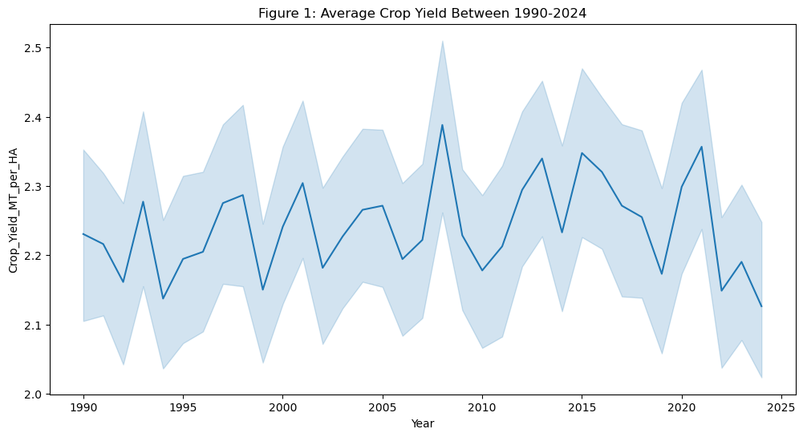

|  | Year | Crop_Yield_MT_per_HA |
| --- | --- | --- |
| 0 | 1990 | 2.230624 |
| 1 | 1991 | 2.216175 |
| 2 | 1992 | 2.161310 |
| 3 | 1993 | 2.277397 |
| 4 | 1994 | 2.137331 |
| 5 | 1995 | 2.194639 |
| 6 | 1996 | 2.204939 |
| 7 | 1997 | 2.275345 |
| 8 | 1998 | 2.286967 |
| 9 | 1999 | 2.150197 |
| 10 | 2000 | 2.241144 |
| 11 | 2001 | 2.304287 |
| 12 | 2002 | 2.181768 |
| 13 | 2003 | 2.227098 |
| 14 | 2004 | 2.265635 |
| 15 | 2005 | 2.271567 |
| 16 | 2006 | 2.194368 |
| 17 | 2007 | 2.222164 |
| 18 | 2008 | 2.388297 |
| 19 | 2009 | 2.228747 |
| 20 | 2010 | 2.177986 |
| 21 | 2011 | 2.212806 |
| 22 | 2012 | 2.294367 |
| 23 | 2013 | 2.339784 |
| 24 | 2014 | 2.233004 |
| 25 | 2015 | 2.347718 |
| 26 | 2016 | 2.320341 |
| 27 | 2017 | 2.271556 |
| 28 | 2018 | 2.255096 |
| 29 | 2019 | 2.173032 |
| 30 | 2020 | 2.298878 |
| 31 | 2021 | 2.356781 |
| 32 | 2022 | 2.148722 |
| 33 | 2023 | 2.190456 |
| 34 | 2024 | 2.126295 |

Crop yield over time was also visualized for each crop type to see if there were any distinct patterns or changes relevant to a specific crop. This was done by grouping the data by the Year and Crop_Type variables and then aggregating by the mean of the Crop_Yield_MT_per_HA variable. However, this plot depicted quite a bit of clutter, and there were no significant crop types that deviated from the patterns shown in the plot above.

After analyzing the Average Crop Yield Between 1990-2024 plot, it was determined that there is no significant relationship between crop yield and time. While the line plot fluctuates between peaks and valleys, the values seem to stay in the same range throughout the years, and there is no general increase/decrease.

**Part 2: Climate Variables Over Time**

The 4 variables that will be utilized in this part are average temperature, total precipitation, CO2 emissions, and extreme weather events. These variables have all been known to contribute to climate change and global warming patterns in the past few decades. For the first three variables, subplots were utilized to depict each variable over time. First, the data was sliced to only include Year, Average_Temperature_C, Total_Precipitation_mm, and CO2_Emissions_MT. This data was then melted using Year as the id_variable. The melted data was then used to form the subplots.

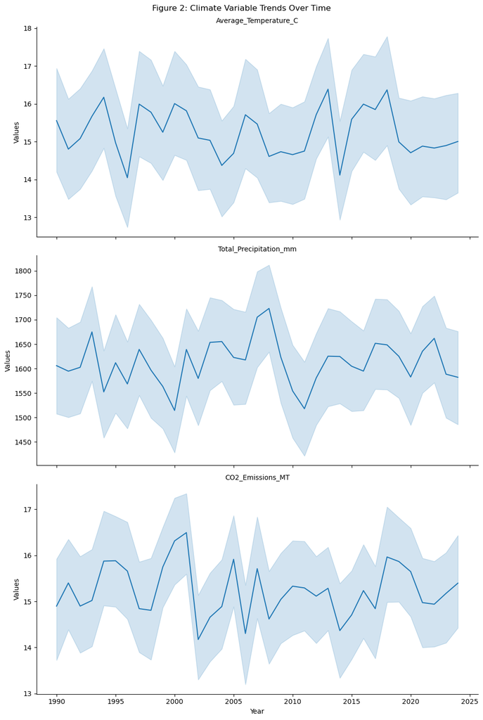

|  | Year | Climate_Var | Mean_Value |
| --- | --- | --- | --- |
| 0 | 1990 | Average_Temperature_C | 15.555680 |
| 1 | 1990 | CO2_Emissions_MT | 14.898240 |
| 2 | 1990 | Total_Precipitation_mm | 1606.037440 |
| 3 | 1991 | Average_Temperature_C | 14.803312 |
| 4 | 1991 | CO2_Emissions_MT | 15.400287 |
| ... | ... | ... | ... |
| 100 | 2023 | CO2_Emissions_MT | 15.174898 |
| 101 | 2023 | Total_Precipitation_mm | 1588.608299 |
| 102 | 2024 | Average_Temperature_C | 15.005694 |
| 103 | 2024 | CO2_Emissions_MT | 15.395872 |
| 104 | 2024 | Total_Precipitation_mm | 1582.257082 |

105 rows × 3 columns

```python
climate_vars = data_cleaned_1.loc[:,['Year','Average_Temperature_C','Total_Precipitation_mm','CO2_Emissions_MT']]

climate_melted = climate_vars.melt(id_vars = 'Year', var_name = 'Climate_Var', value_name = 'Values')

a = sns.FacetGrid(climate_melted, col = 'Climate_Var',col_wrap=1, height=5, aspect=2, sharey=False)
    # sharey ensures each has its own y axis
a.map_dataframe(sns.lineplot, x='Year', y='Values')
a.set_titles("{col_name}")

a.fig.suptitle("Figure 2: Climate Variable Trends Over Time", fontsize=12)
a.fig.subplots_adjust(top=0.95)


plt.show();

display(climate_melted
    .groupby(['Year', 'Climate_Var'], as_index=False)
    .agg(Mean_Value=('Values', 'mean'))
)
```

Just like the crop yield plot from Part 1, these plots don’t show much of a distinct trend. One key point, however, is that there was a large drop in total precipitation between the years 2008-2011. Precipitation returns to normal after that large valley. The remaining plots appear to maintain a relatively consistent range of values, particularly given that their axes do not start at zero.

The final climate variable, Extreme Weather Events, required a different visualization approach due to its binned format. As mentioned previously, this variable was binned due to the original skewedness of the data and to visualize different levels of weather events seperately. Very high levels of extreme weather events can be indicators of climate change. Once the variable was binned, it was grouped by the Year and Extreme_Weather_Events variable and then aggregated by size. Aggregation by size allows for the visualization of number of observations for each level for each year.

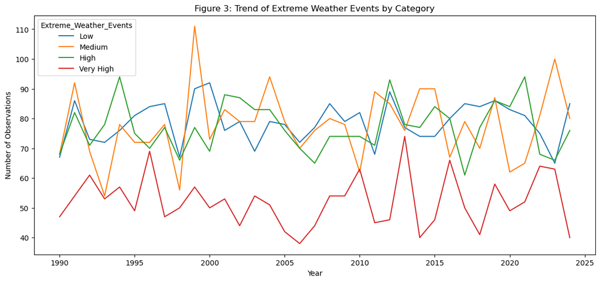

|  | Year | Extreme_Weather_Events | Count |
| --- | --- | --- | --- |
| 0 | 1990 | Low | 67 |
| 1 | 1990 | Medium | 68 |
| 2 | 1990 | High | 68 |
| 3 | 1990 | Very High | 47 |
| 4 | 1991 | Low | 86 |
| ... | ... | ... | ... |
| 135 | 2023 | Very High | 63 |
| 136 | 2024 | Low | 85 |
| 137 | 2024 | Medium | 80 |
| 138 | 2024 | High | 76 |
| 139 | 2024 | Very High | 40 |

140 rows × 3 columns

This plot highlights a key feature of the Extreme_Weather_Events variable. While there are fewer observations of the Very High extreme weather events, it is depicted that this bin has had an increase in activity beginning in the year **2010**. On the plot, this bin is depicted by the red line. From the years **1990-2010**, the peaks and valleys in the line are smaller compared to those following the year **2010**. After this year, the red line depicts rapid rises and falls of levels of extreme_weather_events, which may be indicative of changes in climate on a global scale in recent years.

**Part 3: Agricultural Factors Over Time (Soil Health Index)**

In this final part, I aim to analyze how soil health index varies over time and if there are any overall trends in this variable. This variable was binned primarily because the test for Soil Health Index assigns different ratings to different levels of soil health. I wanted to measure how different levels of soil health vary over the course of the 34 years. After the data was binned in the Data Cleaning section, I grouped the data by Year and Soil_Health_Index and aggregated by size to display the count values for each year and each Soil_Health_Index level. The generated plot is shown below.

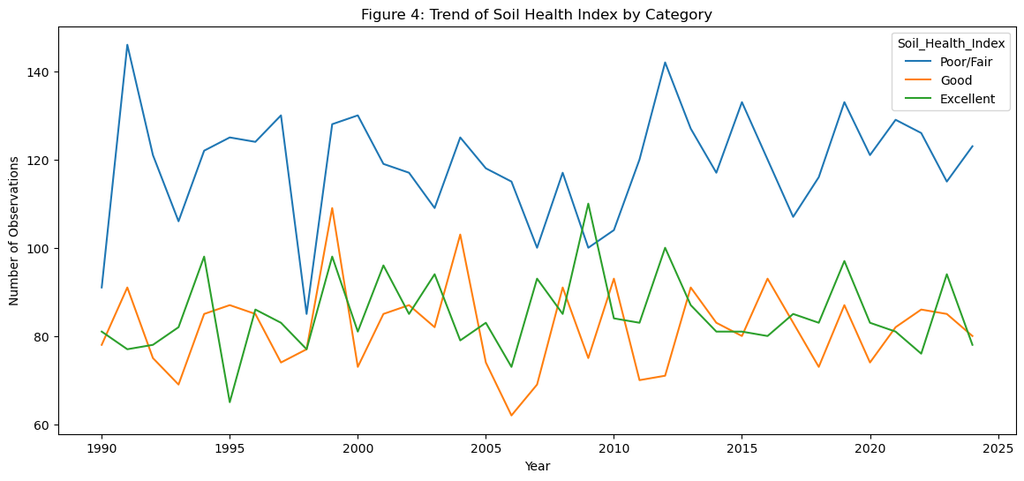

|  | Year | Soil_Health_Index | Count |
| --- | --- | --- | --- |
| 0 | 1990 | Poor/Fair | 91 |
| 1 | 1990 | Good | 78 |
| 2 | 1990 | Excellent | 81 |
| 3 | 1991 | Poor/Fair | 146 |
| 4 | 1991 | Good | 91 |
| ... | ... | ... | ... |
| 100 | 2023 | Good | 85 |
| 101 | 2023 | Excellent | 94 |
| 102 | 2024 | Poor/Fair | 123 |
| 103 | 2024 | Good | 80 |
| 104 | 2024 | Excellent | 78 |

105 rows × 3 columns

A key feature of this plot is that there is a visible difference between the number of observations for Poor/Fair and the other 2 soil health levels. However, it is important to point out that this data was binned in a way that may have contributed to this output. Since the Cornell Health Test only qualifies soil samples with a rating higher than 60 to be functioning without limitation, it groups all samples below a rating of 60 to be poor/fair. This grouping takes up 60% of all available ratings, which contributes to a greater number of observations for this category. This especially makes sense when a histogram of the Soil_Health_Index variable without binning has similar counts throughout all possible ratings. What this data does highlight, however, is that there are overall a larger number of observations for soil samples that are functioning *with* limitations.

**Answer to the Question**

In this analysis, we measured how three distinct categories of variables behave over time: crop yield, climate variables, and agricultural factors. This can put into perspective any trends and patterns that may be significant for the following analysis questions. In **Part 1**, it was found that there is no significant relationship between Crop_Yield_MT_per_HA and Year. The patterns demonstrated in the line plot stay consistent over time and over a small range of values on the y-axis. In **Part 2**, it was again found that there is no relationship Year has with Average_Temperature_C’, Total_Precipitation_mm, and CO2_Emissions_MT. However, a key finding is that when Extreme_Weather_Events was plotted, there seems to be increased activity of the variable in recent years. For this plot, the number of observations doesn’t play a large role, as I am analyzing more of the patterns that the lines show. Finally, in **Part 3**, it was found that there is are overall larger number of observations for soil samples that are functioning *with* limitations. While there are inherent issues with how the data was binned, this conclusion remains true and shows that this has been consistent over the period of years between **1990-2024**.

### b) Analysis 2

*What regions are experiencing the greatest changes in these 3 categories?*

**Part 1: Temperatures Across Regions**

To create a baseline for how each region varied within its country, I plotted the average temperature for each region in each country. This allows for the geographic visualization of how each region differs and how this may contribute to trends seen later on in Analysis 2. Although other variables dictate climate (precipitation, CO2 emissions), temperature is most commonly used as a baseline. For example, in some countries, the temperature varies depending on altitude. This was done by using a pivot table, with the Region as the index, Country as the columns, Average_Temperature_C as the values, and mean as the aggregate function. The pivot table was used to isolate only the columns and values needed for analysis. The pivot table was then melted so that all of the countries would be under one column and their corresponding temperatures would be in the values column. Using the melted pivot table, a multi-plot grid was created. Each subplot represents a country, the categorical variables on the x-axis represent the regions within that country, and the y-axis represents the average temperature in Celsius.

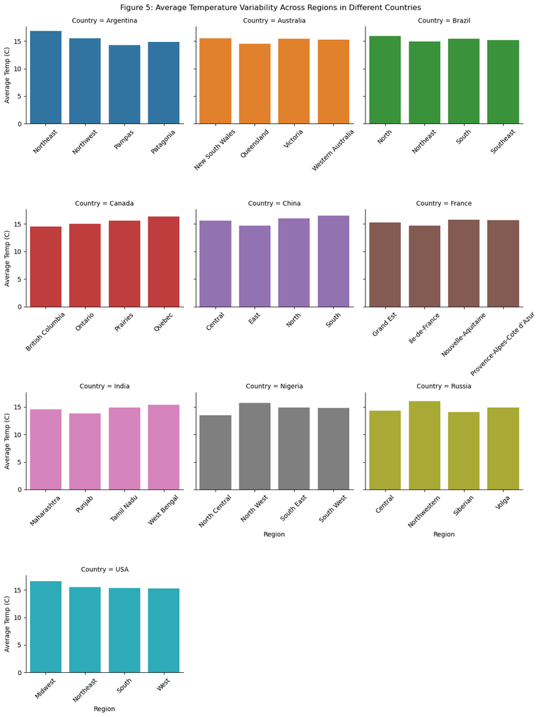

|  | Region | Country | Average Temp (C) |
| --- | --- | --- | --- |
| 11 | Northeast | Argentina | 16.822159 |
| 12 | Northwest | Argentina | 15.489676 |
| 16 | Pampas | Argentina | 14.283929 |
| 17 | Patagonia | Argentina | 14.873614 |
| 41 | New South Wales | Australia | 15.475145 |
| 56 | Queensland | Australia | 14.538775 |
| 63 | Victoria | Australia | 15.406855 |
| 67 | Western Australia | Australia | 15.260045 |
| 76 | North | Brazil | 15.963593 |
| 79 | Northeast | Brazil | 14.923057 |
| 92 | South | Brazil | 15.401770 |
| 95 | Southeast | Brazil | 15.155616 |
| 102 | British Columbia | Canada | 14.539959 |
| 117 | Ontario | Canada | 15.054275 |
| 120 | Prairies | Canada | 15.636091 |
| 123 | Quebec | Canada | 16.349913 |
| 137 | Central | China | 15.604937 |
| 138 | East | China | 14.749853 |
| 144 | North | China | 15.994921 |
| 160 | South | China | 16.515283 |
| 173 | Grand Est | France | 15.299370 |
| 174 | Ile-de-France | France | 14.734110 |
| 184 | Nouvelle-Aquitaine | France | 15.813810 |
| 189 | Provence-Alpes-Cote d’Azur | France | 15.729576 |
| 209 | Maharashtra | India | 14.578869 |
| 224 | Punjab | India | 13.866319 |
| 232 | Tamil Nadu | India | 14.902410 |
| 236 | West Bengal | India | 15.406629 |
| 247 | North Central | Nigeria | 13.527745 |
| 248 | North West | Nigeria | 15.733788 |
| 263 | South East | Nigeria | 14.883000 |
| 264 | South West | Nigeria | 14.781852 |
| 273 | Central | Russia | 14.317709 |
| 285 | Northwestern | Russia | 16.085507 |
| 295 | Siberian | Russia | 14.069309 |
| 302 | Volga | Russia | 14.908046 |
| 312 | Midwest | USA | 16.602055 |
| 317 | Northeast | USA | 15.517452 |
| 330 | South | USA | 15.363536 |
| 337 | West | USA | 15.243424 |

The plot shows that regional temperatures cluster closely together, typically within about 2.5°C of 15.0°C. Even so, the visualization makes it clear that there are still some regional differences, just not particularly large ones. For example, the visualization shows that the Pampas region in Argentina is colder than the Northeast region of Argentina, which is scientifically true [2]. Overall, the limited variation within countries implies that it may be more useful to compare subnational regions at a global scale rather than focusing only on differences within individual countries.

**Part 2: Regions with Greatest Changes in Crop Yield, Extreme Weather Events, and Soil Health Index**

For this part of the analysis, we now want to look at which regions had the greatest changes in the three chosen variables. This helps us identify where the most significant shifts have occurred and which areas may need future study. To keep things simple, I measure the net change between 1990 and 2024. This allows me to clearly identify which regions experienced true long-term shifts, which is more appropriate given that these variable types evolve gradually rather than fluctuating meaningfully from year to year. Furthermore, we are looking for the greatest absolute difference because climate change can cause both increases and decreases that have major consequences, and understanding the size of these shifts matters more than their direction.

After grouping by the Country and Region, I applied a function that would subtract the value of the variable from the first year from the first year. Then the magnitude of this value was used to identify where the biggest change occurred. For each variable, the region-country pairs were then sorted, and the top 10 regions that have exhibited the greatest change for each variable were selected.

These steps were only taken for the Crop_Yield variables and Soil_Health_Index variables because the Extreme_Weather_Events variable have discrete values from 0-10, so a quantifiable difference can’t be measured in the same way as the other two variables.

|  | Country | Region | Crop_Yield_Change | Country | Region | Soil_Health_Index_Change |
| --- | --- | --- | --- | --- | --- | --- |
| 0 | Brazil | Northeast(Brazil) | 2.691 | Brazil | South(Brazil) | 54.30 |
| 1 | France | Ile-de-France(France) | 2.549 | Russia | Siberian(Russia) | 49.48 |
| 2 | Argentina | Northeast(Argentina) | 2.521 | France | Nouvelle-Aquitaine(France) | 49.32 |
| 3 | Russia | Northwestern(Russia) | 2.520 | Argentina | Northwest(Argentina) | 45.44 |
| 4 | Brazil | North(Brazil) | 2.069 | Russia | Northwestern(Russia) | 43.93 |
| 5 | Brazil | Southeast(Brazil) | 2.023 | India | Punjab(India) | 42.70 |
| 6 | USA | South(USA) | 1.878 | Argentina | Patagonia(Argentina) | 42.04 |
| 7 | India | West Bengal(India) | 1.701 | India | Maharashtra(India) | 41.52 |
| 8 | Argentina | Northwest(Argentina) | 1.700 | Argentina | Northeast(Argentina) | 35.92 |
| 9 | Russia | Volga(Russia) | 1.673 | Argentina | Pampas(Argentina) | 32.90 |

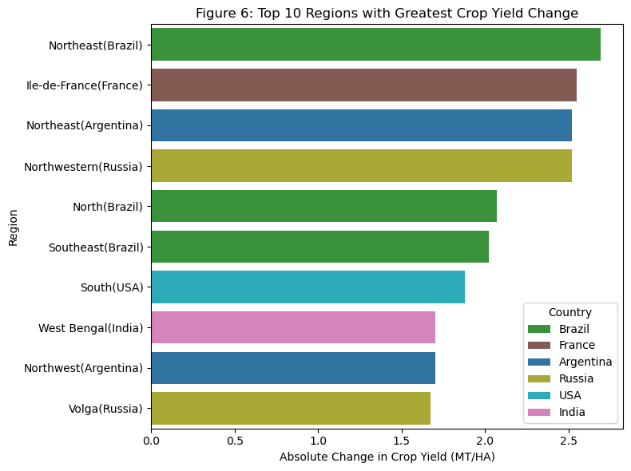

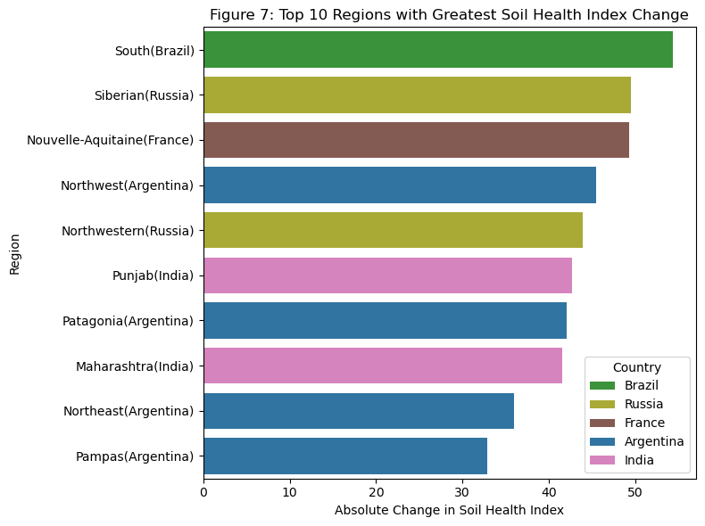

Finally, we examine the variable Extreme_Weather_Events to identify the regions with the greatest change. Because these events are already binned, we want to see which countries have the highest counts of Very High Levels because this indicates which regions are experiencing the most extreme weather, which is particularly relevant for assessing climate risk and vulnerability. It may also be interesting to see how each level of extreme weather events varies per country. Therefore, a heatmap can display countries on the y-axis and extreme weather event levels on the x-axis. For simplicity, we analyze data at the country level rather than by region, since there are 40 regions and including them would make the heatmap too noisy without revealing clear patterns.

For this, a pivot table was created with the Country as the index, Extreme_Weather_Events as the columns, and the aggregation by size. The heatmap was then generated using this data.

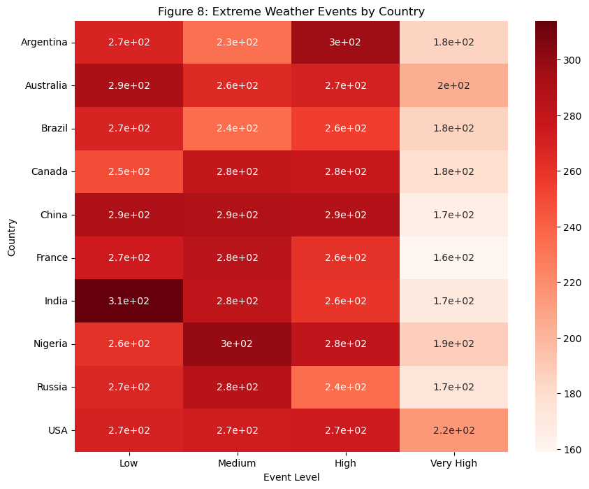

**Answer to the Question**

This question aimed to identify which regions/countries are most affected by changes in agricultural and climate variables. For Crop Yield and Soil Health index, this meant looking at net change over the set of years. For Extreme Weather Events, this meant looking at which countries currently experience the highest levels at each category.

The region with the greatest change in Crop Yield over time was Northeast Brazil, with a magnitude of 2.691. The region with the greatest change in Soil Health Index over time was South Brazil, with a magnitude of 54.30. The primary countries present in the top 10 across both variables are Brazil, appearing 4 times; Argentina, appearing 6 times; and Russia, appearing 4 times. These regions and countries have had the greatest changes in Crop Yield and Soil Health Index, respectively, on a global level across the years 1990-2024.

For Extreme Weather Events, India had the highest level of Low Extreme Weather Events, Nigeria had the highest level of Medium, Argentina had the highest High, and the U.S. had the highest Very High. While these results do not measure change over time, they highlight which countries are experiencing the most extreme weather events at each level. For example, since the U.S. has the highest number of Very High events, it shows climate impacts are most severe in this country. This information provides a regional analysis of this variable, which can be used as a baseline for future change analysis.

### c) Analysis 3

*How do climate change factors correlate with crop yield?*

For this question, we wanted to measure how well climate change factors (temperature, precipitation, CO2 emissions, and extreme weather events) correlated with crop yield. As the average temperature increases, does crop yield go down? Is there a lower crop yield when there are higher levels of extreme weather events? I also chose to include Soil Health Index in this analysis because it is a strong variable to include in the heatmap. We should expect crop yields to go up with higher soil health indices.

For this analysis, not much data wrangling/aggregation needed to be done. The important columns were filtered out from the original data and were correlated with each other to form the basis for the heatmap. The results were then visualized, with lighter colors indicating low levels of correlation and vibrant colors indicating high levels of correlation.

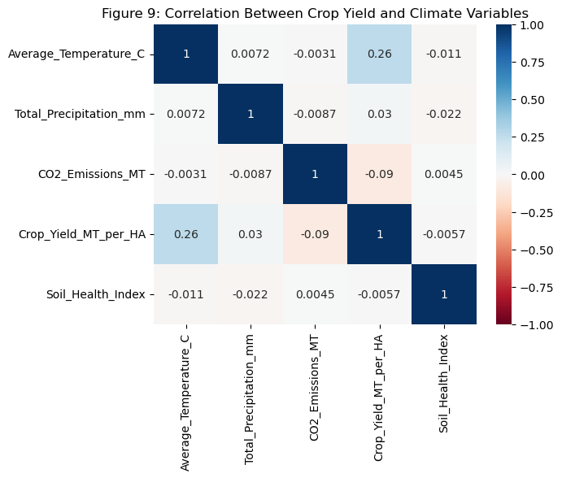

It is depicted that, aside from self-correlations, Crop Yield and Average Temperature show the highest correlation in the data. This relationship was visualized further using a scatterplot with the Average Temperature on the x-axis and Crop Yield on the y-axis.

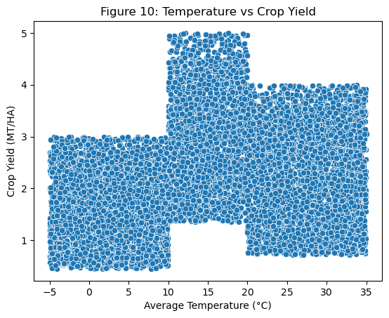

Because Extreme_Weather_Events is a binned variable, instead of using traditional correlation, I choose to measure the distribution of crop yields across categories of extreme weather events using boxplots. This allows us to determine which categories of extreme weather events have higher/lower median yields and the variability in yields. Given known facts about climate change, it is expected that categories with more extreme weather events show lower median crop yields and wider variability in yields, because some farms may be more resilient than others. Since it was determined in a previous question that the USA has the highest level of Very High extreme weather events, I was curious to see how this translated to this question. A similar plot depicting all countries was used for comparison.

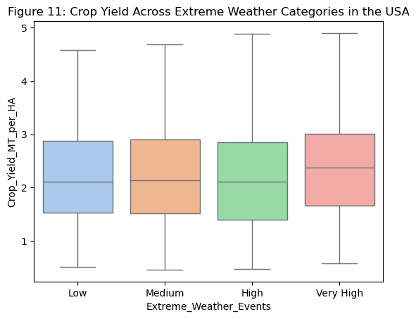

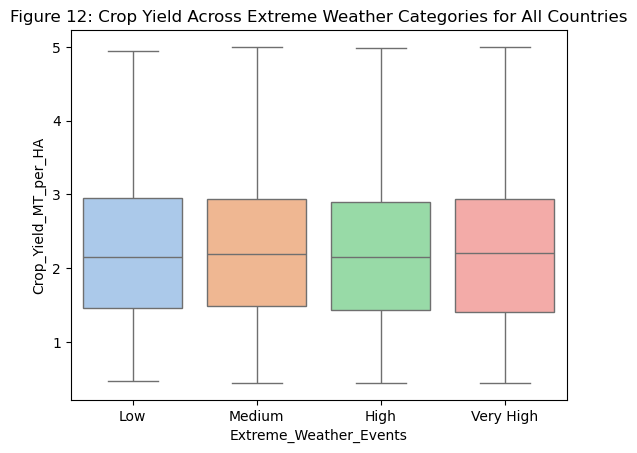

```
USA Crop Yield Summary by Extreme Weather Events
```

| Extreme_Weather_Events | count | mean | std | min | 25% | 50% | 75% | max | Range |
| --- | --- | --- | --- | --- | --- | --- | --- | --- | --- |
| Low | 270.0 | 2.196337 | 0.932528 | 0.513 | 1.530 | 2.1105 | 2.8755 | 4.58 | 4.067 |
| Medium | 273.0 | 2.214839 | 0.932913 | 0.459 | 1.512 | 2.1330 | 2.9000 | 4.68 | 4.221 |
| High | 274.0 | 2.201522 | 1.010211 | 0.468 | 1.395 | 2.1120 | 2.8530 | 4.89 | 4.422 |
| Very High | 215.0 | 2.366972 | 0.964928 | 0.570 | 1.658 | 2.3760 | 3.0045 | 4.90 | 4.330 |

```
Global Crop Yield Summary by Extreme Weather Events
```

| Extreme_Weather_Events | count | mean | std | min | 25% | 50% | 75% | max | Range |
| --- | --- | --- | --- | --- | --- | --- | --- | --- | --- |
| Low | 2755.0 | 2.236892 | 0.982763 | 0.468 | 1.45800 | 2.1600 | 2.951 | 4.94 | 4.472 |
| Medium | 2724.0 | 2.259086 | 1.001251 | 0.450 | 1.48875 | 2.1885 | 2.934 | 5.00 | 4.550 |
| High | 2696.0 | 2.224329 | 1.003056 | 0.450 | 1.43100 | 2.1500 | 2.892 | 4.99 | 4.540 |
| Very High | 1825.0 | 2.239447 | 1.010630 | 0.450 | 1.41300 | 2.2140 | 2.934 | 5.00 | 4.550 |

**Answer to the Question**

For this question, we wanted to measure and visualize the correlations and relationships between climate variables and crop yield to understand how these factors influence agricultural productivity.

One key finding was that crop yield is the highest when Average Temperature varies between **10 - 20 (°C)**. Although this is an effect of the synthesized nature of the data, it is still meaningful as a finding through the trends visualized.

### d) Analysis 4

*How do climate change and agricultural practices collectively influence economic impact from crop production globally?*

Since this is a general question, we can divide it into two primary sub-questions. How does economic impact relate to crop yield? How does economic impact differ across countries and how does crop yield differ across adaptation strategies and extreme weather events? For example, we might expect that more developed countries have a greater economic impact, or certain adaptation strategies might yield a higher crop yield.

Beginning with the latter, barplots were used to measure these relationships. They can visually demonstrate the effects different categories have on economic impact. For each plot, the categorical variable is on the x-axis, and Economic_Impact_Million_USD or Crop_Yield_MT_per_HA is on the y-axis. To quantify the mean Economic_Impact_Million_USD for each category in each variable and the standard error bars (sem), each variable was grouped by the variable, and Economic_Impact_Million_USD was used to aggregate values by mean, standard deviation, and count. A function to calculate error was also used. The same was done for the graphs using Crop_Yield_MT_per_HA.

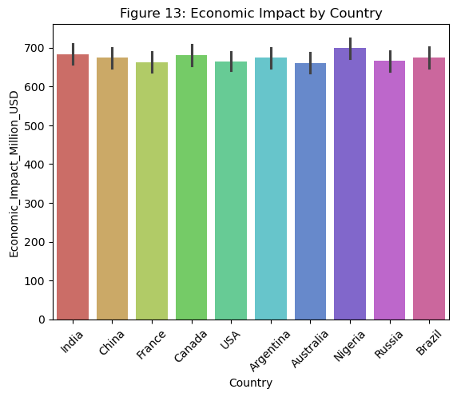

```
Economic Impact by Country
     Country        mean         std  count        sem
0  Argentina  674.055935  416.156121    984  13.266573
1  Australia  660.917752  418.982861   1032  13.042367
2     Brazil  675.135339  412.385134    944  13.421993
3     Canada  680.121931  410.546507    984  13.087745
4      China  674.689835  416.854107   1031  12.982393
5     France  663.225501  404.198313    978  12.924837
6      India  683.412673  418.990602   1025  13.087068
7    Nigeria  699.281147  429.024206   1029  13.374394
8     Russia  666.132914  417.119406    961  13.455465
9        USA  665.057074  400.749492   1032  12.474787
```

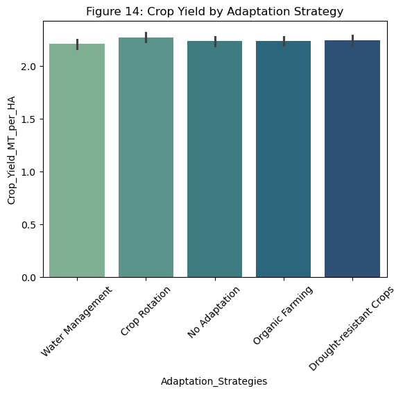

```
Crop Yield by Adaptation Strategy
     Adaptation_Strategies      mean       std  count       sem
0            Crop Rotation  2.271590  1.012447   1957  0.022886
1  Drought-resistant Crops  2.244425  0.991208   1995  0.022192
2            No Adaptation  2.237939  1.001804   2024  0.022268
3          Organic Farming  2.238188  0.982698   1975  0.022112
4         Water Management  2.209385  1.003231   2049  0.022163
```

These bar plots show that there are no clear trends or patterns when comparing these categorical variables to economic impact and crop yield. Most of the error bars overlap across categories, suggesting that the differences between bars are likely not statistically significant. While this result was unexpected, it indicates that the variables initially thought to have the greatest economic influence do not, and can therefore be ruled out as major factors in the overall analysis. For instance, there is now evidence of minimal differences in economic impact across countries and crop yield across adaptation strategies.

Finally, I chose to measure the relationship between economic impact and crop yield using a regression plot. The regression plot displays individual data points and automatically fits a regression line through the data, as well as a confidence interval around the regression line. When initially generating the regression plot, the data were incredibly dense, and the best-fit line was unnoticeable. So for this visualization, I chose to sample the dataset to depict the same relationship but with fewer data points.

- Note: Since this course doesn’t cover linear regression, it is difficult to get the function for the regplot and confidence interval. Therefore, the exact numerical representation is unavailable for this plot.

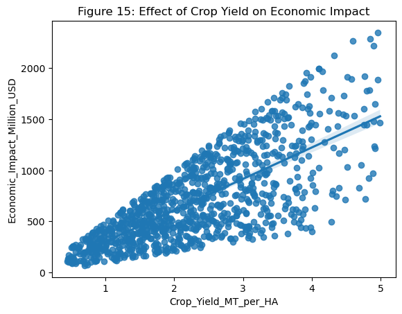

```
Correlation between economic impact and crop yield: 0.7263578606973355
```

**Answer to Question**

For this question, I aimed to measure how the economic impact differs across different categorical variables and the relationship between economic impact and crop yield. For the first part of this goal, it was concluded that there is no significant difference in economic impact between countries and crop yield across adaptation strategies. While this was unpredictable, it does tell us that these three variables do not provide meaningful variation to consider further when doing the full analysis of the dataset. For the second part of this goal, a correlation value of 0.726 indicates a strong positive linear relationship between crop yield and economic impact. As crop yield increases, economic impact tends to increase as well. This is a highly valuable insight because it signifies that if strategies are implemented to increase crop yield, economic impact will increase as well.

## 7) Recommendations to Stakeholders

As a reminder, the key stakeholders for this project include agricultural producers, policymakers, and environmental organizations. It is important to emphasize that the dataset used in this study is fully synthesized for educational purposes. Therefore, any recommendations derived from the analysis should not be interpreted as real-world guidance. Nonetheless, for the purposes of this project, recommendations will be formulated based on the patterns and trends identified in the data.

### a) Recommendations 1

For Analysis 1, it was concluded that there is no significant relationship between Crop_Yield_MT_per_HA and Year, there are no patterns Average_Temperature_C, Total_Precipitation_mm, and CO2_Emissions_MT have with across the set of years, there has been increased activity in Very High levels of Extreme_Weather_Events in recent years, and there is are overall larger number of observations for soil samples that are functioning *with* limitations.

For agricultural producers, this indicates that steps need to be taken to improve soil health overall. The ratio between soil samples functioning *with* limitations and soil samples functioning *without* limitations is far too great, regardless of the year. Strengthening soil health practices may help control vulnerabilities in crop production long-term.

Since no clear trends were found between climate variables and yield over time, policymakers should invest in research to better understand the patterns of climate change. This study alone does not provide strong enough evidence of climate change, but more long-term and scientific datasets are needed to capture these patterns and inform effective policy. From the findings on soil health, policymakers should also prioritize funding for soil restoration and monitoring programs to improve long-term agricultural productivity.

For environmental organizations, it is recommended that they collaborate with researchers and policymakers to learn more about patterns of climate change and environmental practices. Environmental organizations can also translate the findings on soil health and extreme weather events into accessible educational materials to inform the public on how the environment has been progressing in recent years.

One important limitation of these recommendations is that they were measured with a relatively short time span (the years 1990-2024). To accurately measure climate change and conduct further analysis, it is recommended that stakeholders invest in research that collects data spanning back as far as possible. Another limitation is the limited variables used. This analysis does not include agricultural variables that may affect later aspects of the full study. Repeating the analysis using these variables over time may increase insights on actions that can be taken.

### b) Recommendations 2

From Analysis 2, it was concluded that the most significant regions in the variables measured (changes in crop yield and soil health index, respectively) were Northeast Brazil and South Brazil. The primary countries appearing in the top 10 across both variables were Argentina, Brazil, and Russia. For Extreme Weather Events, India had the highest level of Low Extreme Weather Events, Nigeria had the highest level of Medium, Argentina had the highest High, and the U.S. had the highest Very High.

These conclusions help identify which countries and regions agricultural producers, policymakers, and environmental organizations should prioritize when allocating time and resources.

One recommendation for these stakeholders is targeting soil health interventions across Brazil, specifically Northeast and South Brazil. These were the two regions that saw the most change in crop yield and soil health index over the time period **1990-2024**. Some examples of soil health interventions include soil restoration programs and sustainable farming initiatives. Additional support could also be provided to Argentina and Russia.

Another recommendation for these stakeholders is to tailor extreme weather prevention strategies to those who have experienced the highest levels of extreme weather events. Since India had the highest count of low levels of extreme weather events, it could maintain any resilience programs it has and invest more into other policies and programs. For the USA, however, it is recommended that they allocate more resources to programs that alleviate the risk of extreme weather. This could include emergency response tactics and more advanced forecasting systems.

One important limitation for this recommendation is that the overall change in crop yield and soil health index is measured by magnitude, not direction. A large numerical change does not necessarily reflect a severe problem. Changes could reflect natural variability, improved measurement, or positive developments rather than environmental degradation. While this was important for climate change, measuring direction in further study can show improvement or a shift to poor impacts.

### c) Recommendations 3

Based on these conclusions, it is recommended that agricultural producers prioritize growing crops in regions that are within the **10 - 20 (°C)** temperature range. While these values may vary slightly depending on crop type, the data shows that for this dataset, it can be beneficial to use a **10 - 20 (°C)** range to produce a higher crop yield. Furthermore, it is recommended that policymakers invest in these regions by providing technology, equipment, and agricultural resources to incentivize producers to grow in these areas.

Because the median crop yield in the USA associated with Very High extreme weather events was slightly higher than that of other countries, it is indicative that the USA may be implementing techniques or technology that make it more resilient to extreme weather and produce a higher crop yield. It is recommended that environmental organizations study the USA further to see how it takes on extreme weather and apply it to areas where crop yield is lower due to high levels of extreme weather. They can also provide information and resources to these other areas, including climate-resistant farming techniques and strong irrigation systems.

One limitation of this recommendation is that the identified 10–20°C optimal range is based on aggregated data across many crops. Individual crops have very different temperature requirements, so recommending producers shift production to this range may not be appropriate without crop-level analysis. Studies on different crop types and their preference towards certain temperatures may shift the insights in a different direction.

### d) Recommendations 4

Analysis 4 concluded that there is no significant difference in economic impact between countries and crop yield across adaptation strategies. Furthermore, as crop yield increases, economic impact tends to increase as well.

For agricultural producers, these conclusions demonstrate that it may not be worth changing adaptation strategies to increase crop yield. Water management, crop rotation, no adaptation, organic farming, and drought-resistant crops do not differ in crop yield, so it is recommended that agricultural producers invest more time and money in moving to areas that fit in the recommended temperature range from Recommendation 3, for example.

For policymakers and environmental organizations, given that the data revealed no significant differences in economic impact across countries, it is recommended to prioritize strategies that strengthen climate adaptation and soil health globally, rather than assuming certain regions face uniquely severe challenges. This may include investing in research to identify effective techniques, equipment, and agricultural practices that enhance crop resilience to climate stressors. Furthermore, because the analysis showed that economic impact rises as crop yield increases, additional research could help uncover factors not captured in this study that further increase crop productivity.

One limitation of this recommendation is that adaptation strategies may not necessarily be comparable. For example, it may not be accurate to compare water management to crop rotation due to variation in scale, quality, and local conditions. Discussing this limitation with environmental scientists may be useful to accurately identify which adaptation strategies are best used for certain crop types. Another limitation of this recommendation is that economic impact may vary due to subsidies, labor costs, market access, and reporting practices. A deeper investigation into how this data was collected may impact results and their connection to crop yield.

# 8) Conclusion

Extreme_Weather_Events is another variable that demonstrated significant patterns across analysis questions. To begin, Very High levels of extreme weather events have experienced an increase in recent years. Then it was found that the USA has the highest count of Very High level of extreme weather events. Finally, the USA has a higher median of crop yield under the Very High level of the extreme weather events category compared to all countries globally. Together, this indicates that the USA may be employing effective strategies or innovations that help maintain crop productivity under severe weather conditions, and further study of these approaches could provide insights for other regions experiencing the increased activity of climate risk.

Overall, these analyses collectively point to the need for region-specific climate strategies and investments in agricultural systems that are optimized for ideal temperature ranges, improved resilience to extreme weather, and even enhanced soil health. These insights together guide stakeholders in promoting agricultural productivity and controlling the consequences of climate change.

## References

[1] Comprehensive Assessment of Soil Health, wilkincounty.gov/vertical/sites/%7B6E7AB7CB-4769-4357-B6C8-90E546FFE488%7D/uploads/2021_Cornell_Comprehensive_Assessment_of_Soil_Health_Plot_4_STwCC.pdf. Accessed 10 Dec. 2025.

[2] Argentina - Climate, Subtropical, Alpine | Britannica, www.britannica.com/place/Argentina/Climate. Accessed 10 Dec. 2025.